# Mapping Economic Partners with flagfillr

Robert Myles McDonnell

2018-02-10

Recently I wrote a little package for R called flagfillr (you can read more details [here](https://github.com/RobertMyles/flagfillr)). One of the main reasons I made this is because I had seen a few maps of economic partners, for example this one, from [here](http://drunkeynesian.blogspot.com.br/2017/11/o-que-os-estados-brasileiros-exportam.html):

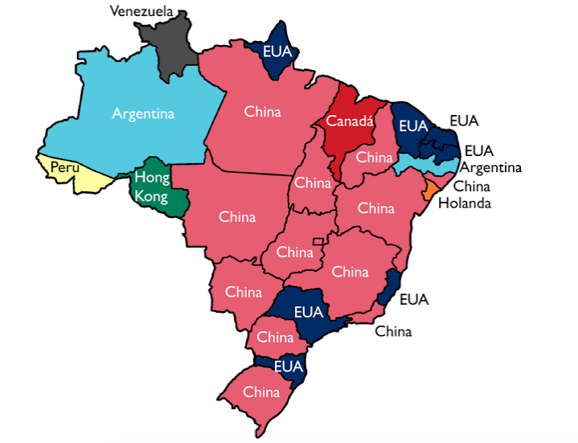

These types of maps (some more [here](http://www.businessinsider.com/us-state-import-export-international-trade-partner-map-2017-11), of the US) are interesting visual summaries, but they look a little *Excel* to me (sorry, whoever made it!). I thought I could spice them up with flags, cos hey, who doesn’t like cool flags (like Bhutan, , awesome!)

## Enter `flagfillr`

With flagfillr, the above map can easily be created. Once you have a data.frame of the data (here I refer to it as `DF`), you can do it with one line:

```r
flagfillr::flag_fillr_data(data = DF, country = "Brazil", resolution = "large",
                           size = "250")
```

Which, if your data corresponds to the map above, will give you this:

[figure not shown]

## Mapping Economic Partners

So how can you do this for another country? Let’s take the example of Australia, from data available [here](http://dfat.gov.au/trade/resources/trade-at-a-glance/Pages/goods-by-state.aspx). First of all, we’ll need to put our data into a dataframe, preferably with columns named `country`, `state` and `partner`, just to keep things simple. Simple is good. I’ll use `dplyr` here (don’t forget you’ll have to install flagfillr, see [here](https://github.com/RobertMyles/flagfillr)). Since Australia’s main trade partners by state are basically China and Japan, let’s choose the *third* biggest trade partner by state, just to keep things interesting.

[figure not shown]

```r
library(dplyr)
library(flagfillr)

oz <- tibble(
  country = "Australia",
  state = c("Northern Territory", "Western Australia", "New South Wales",
            "South Australia", "Victoria", "Queensland", "Tasmania",
            "Australian Capital Territory"),
  partner = c("India", "United Kingdom", "South Korea", "Malaysia", "New Zealand",
              "India", "Malaysia", "Malaysia")
)

flag_fillr_data(oz, country = "Australia", type = "state", size = "250",
                partner_col = oz$partner, state_col = oz$state)
```

It’s not surprising that we see these countries here (the principal partners are China, Japan and India). Indeed, for many countries, the main economic partners are not a surprise. Let’s take a look at the mainland United States. We can recreate these plots with flagfillr (for more detailed data see [here](https://www.census.gov/foreign-trade/statistics/state/data/index.html)), and make them a little prettier (they come from [here](http://www.businessinsider.com/us-state-import-export-international-trade-partner-map-2017-11)).

[figure not shown]

[figure not shown]

First, let’s make the data:

[figure not shown]

```r
states <- state.name
imports <- tibble(
  state = states,
  partner = NA_character_
) %>%
  mutate(partner = case_when(
    state %in% c("Oregon", "Indiana") ~ "Ireland",
    state == "Louisiana" ~ "Saudi Arabia",
    state == "Alabama" ~ "South Korea",
    state %in% c("South Carolina", "Maryland", "Rhode Island") ~ "Germany",
    state == "Delaware" ~ "United Kingdom",
    state %in% c("Texas", "Arizona", "Utah") ~ "Mexico",
    state %in% c("Washington", "Montana", "Wyoming", "Colorado", "North Dakota",
                 "South Dakota", "Iowa", "Oklahoma", "West Virginia", "Maine",
                 "New Hampshire", "Vermont", "Massachusetts", "Connecticut") ~"Canada",
    TRUE ~ "China"
  ))


flag_fillr_data(imports, country = "United States", type = "state", size = "250",
                partner_col = imports$partner, state_col = imports$state)
```

Maybe that’s a slightly disturbing vision to some people haha! I like to think it’s a nice reminder of how intertwined our world is. And some surprises in there…Ireland, South Korea, Saudi Arabia. It’s probably to do with US Multinationals abroad in the Irish case, maybe with German maunfacturers in the US in the German case…I’m not sure, I’ll leave it to the experts. How about the countries that these states most export to?

[figure not shown]

```r
exports <- tibble(
  state = states,
  partner = NA_character_
) %>%
  mutate(partner = case_when(
    state %in% c("Oregon", "Washington", "Louisiana", "South Carolina") ~ "China",
    state == "Nevada" ~ "Switzerland",
    state %in% c("Utah", "Delaware") ~ "United Kingdom",
    state %in% c("Wyoming", "Florida") ~ "Brazil",
    state == "Connecticut" ~ "France",
    state %in% c("California", "Texas", "Arizona", "New Mexico", "Nebraska",
                 "Kansas") ~ "Mexico",
    TRUE ~ "Canada"
  ))


flag_fillr_data(exports, country = "United States", type = "state", size = "250",
                partner_col = exports$partner, state_col = exports$state)
```